Assigned on Monday, 9 April 2018, due 21:00 on Sunday, 22 April 2018

1. This is an exercise in efficient computation in R. Borrowed shamelessly from Emrehan Halıcı’s “Zeka Oyunları” page in *TÜBİTAK Bilim ve Teknik* Magazine, April 2018 issue.
   1. Find all three-digit numbers $ABC$ such that $A+B^2+C^3$ equals the same as the number itself. Do it with R’s functions, but do not use while/for loops.
   2. Solve the same problem by writing a C++ extension with Rcpp package.
   3. How about if you extend the question to six digits?
2. KarÇelik produces refrigrators in three shifts (first, second, and third) in proportion to 4:2:1, because employees work approximately in the very similar proportions in those shifts everyday. Therefore, the chief of the quality control department expects the number of defective refrigirators produced in those three shifts to follow those same proportions. To check if this is correct, she counted total number of defective refrigirators produced in each shift during the last week:

   |  | First shift | Second shift | Third shift |
   | --- | --- | --- | --- |
   | Number of Defective Refrigirators | 20 | 16 | 14 |

   Do the defective refrigirator rates of the shifts follow the same production rates of those shifts?
3. Multinational CarKill Co. is working on four potential pesticides to kill a certain species of beet fly. Independent random samples of 200 flies are exposed to each of those four pesticides, and the number of dead flies after 12 hours of exposure are reported in the following table:

   | Observed Counts | Pesticide A | Pesticide B | Pesticide C | Pesticide D |
   | --- | --- | --- | --- | --- |
   | Dead | 124 | 147 | 141 | 142 |
   | Alive | 76 | 53 | 59 | 58 |

   Are the rates of kill of four pesticides the same or at least one of them is different than others?
4. The following table reports the number of operators in a construction company with specific number of accidents over a fixed period of time:

   | Number of accidents per operator | 0 | 1 | 2 | 3 | 4 | $\ge5$ |
   | --- | --- | --- | --- | --- | --- | --- |
   | Number of operators | 296 | 74 | 26 | 8 | 4 | 6 |

   Does the number of accidents follow Poisson distribution?
5. The following data mark each day when a child suffered an asthma attack (1 attack, 0 no attack) for 110 consecutive winter days (listed rowwise).

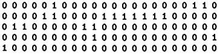

   Which model explain the data best?
   1. i.i.d. Bernoulli trials,
   2. first-order Markov chain,
   3. second order Markov chain?
6. (Continued) On each of those 110 days, the smoke concentration in the air in the neighborhood of the child has also been measured as follows:

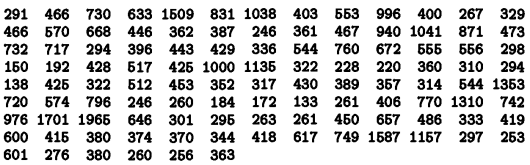

   Is there an association between the child’s asthma attacks and smoke concentration in the neighborhood?